# The Gender Gap in Compensation among UK firms

An-Chiao Liu, Gabriel Naylor-Leyland & Jasper Ginn

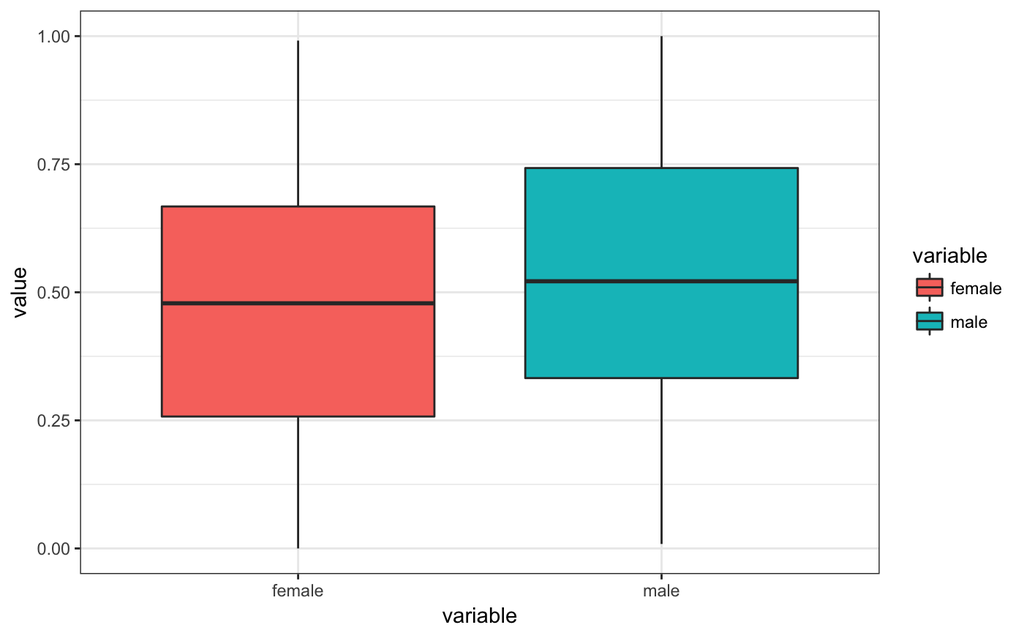

# Introduction

The Gender Pay Gap defines the difference in hourly wage between men and women. This can be measured either by the mean wage, the median wage, or any other average. It is of interest not only to assess the size of the gender gap across a population, but also to uncover the driving factors behind its existence. For instance, are certain high-wage industries dominated by male workers? Does the population wage gap increase in positions of high wage? Do men and women earn comparable salaries for comparable jobs?

This report will focus on the wage gap in the UK in 2017. The data we analyse throughout the report comprise all companies with over 250 employees, and a small amount of smaller companies. As of 2017, it is required by the UK government that all such companies publish information pertaining to the pay of employees for the purpose of showing whether there is indeed a difference in the pay of male and female employees. This dataset is thus well protected against non-response errors, given that failure to comply with the regulations can lead to enforcement from the Equality and Human Rights Commission [1]. In addition, non-sampling errors are also well protected via the use of clear and simple categories, for example, size brackets for the number of employees. Our aim is to create an efficient sampling design, from which we can make accurate calculations by using a smaller sample. We will compare the precision of a number of different such designs. Their accuracy will be measured against the results obtained from the complete data analysis.

One element of the data which we will refer to throughout this report is the Standard Industrial Classification (SIC). This is a widely used system for classifying companies into certain larger industries. Another important variable in the data is the EmployerSize, which categorises each company into seven distinct sizes: size not provided, less than 250, 250 to 499, 500 to 999, 1000 to 4999, 5000 to 19,999, and 20,000 or more. We will discuss in detail whether using information on the gender pay gap within these categories can lead to better sampling designs.

Before conducting our analysis, we first made some modifications to the dataset. Firstly, the information that was not necessary was stored in a separate dataframe, which we did not use. For example, the person responsible for the submission of the data was not relevant, and was thus not included in our main dataset. For our analysis, 6 companies were removed, for reasons explained further in the sampling section. We thus finally performed our analyses on the dataset with 6707 companies.

# Population data analysis

```r
hist(gpg_core$DiffMeanHourlyPercent, main = "Gender gap in mean hourly pay (%)", xlim = c(-1, 1), xlab = "Size of pay gap")
```

[output not shown]

A glance at the distribution of both positive and negative wage inequalities again proves interesting: 902, or 13.45%, of UK companies pay a higher median wage to women in comparison to men - a significantly smaller figure than the 5257 companies, or 78.38%, who provide a higher median wage to males. (The remaining 548 companies, or 8.22%, provide an equal median wage). Similarly to the analysis of the mean wage, we can see from the histogram (Figure 3) that the distribution is strongly skewed in favour of higher male income.

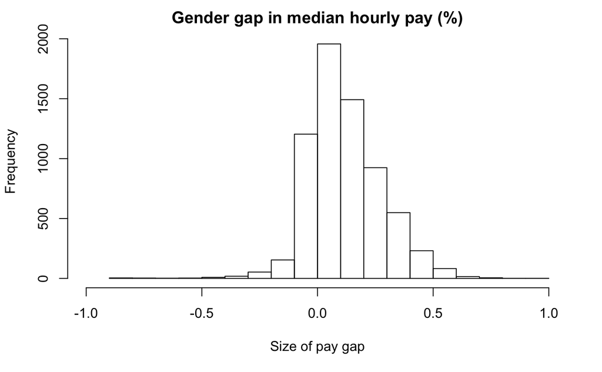

Using the data on the gender of employees working within each income quartile (herein referred to as lower, lower middle, upper middle, top), we were able to get a sense of the distribution of employees at the company level. For example Figure 4 shows that a higher concentration of women currently work in the lower quartile, while male employees dominate the top and upper middle quartiles. This is likely to be one of the driving factors behind the 14.4% nation-wide pay inequality. However, in order to further this analysis, we would require data pertaining to the size of the gender pay gap within each income quartile. For example, we know that males dominate the top quartile - and females the lower quartile - but we do not know in which quartile is the pay gap more pronounced.

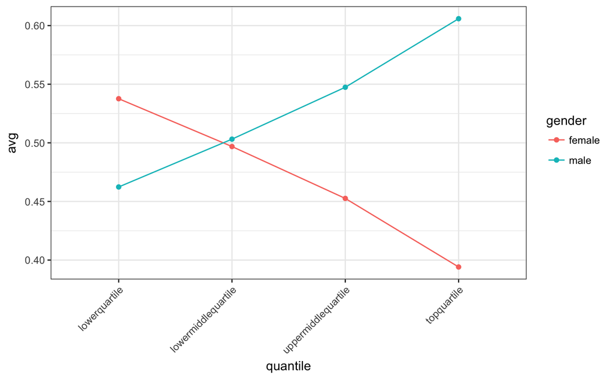

# Sampling methods

The focus of this report largely falls on sampling methods, with the aim of making inferences on the target population using a (smaller) designed sample. The target population for our sampling was the UK working population; the goal of assessing the gender wage gap was to do so in the context of its widespread presence in the entire population. In the current situation, whereby companies with over 250 employees are required to provide relevant data, we worked with a dataset containing 6707 companies. The sample size in mind when conducting the following sample analyses will be 1000. Thus, we endeavour to make calculations related to the gender pay gap on such a sample which accurately reflect the UK population.

Firstly, we opted to generate a sample of 1000 random companies out of the 6707 available, with each company given an equal probability of being sampled (1000 / 6707 = 14.9%). This method is known as a simple random sample (SRS), and requires the assumption that a random sample is representative of the target population. The sample is taken without replacement, i.e. no company can be included more than once in the sample.

```r
CI <- data.frame(
  "lower" = c(paste0(round(srs_mean[1] - marginerror[1], digits=4) * 100, "%"),
              paste0(round(srs_mean[2] - marginerror[2], digits=4) * 100, "%")),
  "upper" = c(paste0(round(srs_mean[1] + marginerror[1], digits=4) * 100, "%"),
              paste0(round(srs_mean[2] + marginerror[2], digits=4) * 100, "%"))
)
row.names(CI) <- c("Mean", "Median")
knitr::kable(CI)
```

[output not shown]

The standard error for the estimate for the difference in mean hourly wage using the SRS is 0.0041. Using this sampling design, we achieve a margin of error of 0.0041*1.96 = 0.8% at the 5% level. This relates to the sampling error - the difference between the sampled statistic and the population statistic is just 0.8%. We will use this SRS as a reference to compare all future sampling designs against, with the aim of creating a sampling design with a small standard error - this will indicate a small sampling error. These comparisons will be done via the design effect $\frac{Variance_{design}}{Variance_{SRS}}$.

When the statistic of interest (here, gender wage inequality) is known to correlate in some way with information provided in the sampling frame, it can be useful to stratify. Arranging the data into strata prior to sampling can optimise the sampling design in the sense that the standard error of the ‘predictions’ can be reduced, thus improving the precision. This will only be the case if we see small variance within the strata, and larger variance between the strata. This will make for a more efficient design for the reason that, if a large portion of the total variance is between the strata, only a small sample from each stratum will be necessary to make accurate predictions.

Based on rudimentary analysis of the two potential stratification variables SIC and EmployerSize, and with the sample of 1000 still the goal, we decided to stratify based on SIC division. Evidence supporting this decision is provided in Figure 5: violin plots of the strata. From these plots we can clearly rule out EmployerSize as a useful stratification variable given the great variation in wage difference within each employer size category. Additionally, post-hoc tests following an ANOVA on the different categories of EmployerSize revealed very little evidence of between-group differences (only one of the 21 pairwise comparisons showed a significant difference). On the contrary, running an ANOVA on the SIC divisions yielded many significant pairwise differences in the median pay gap.

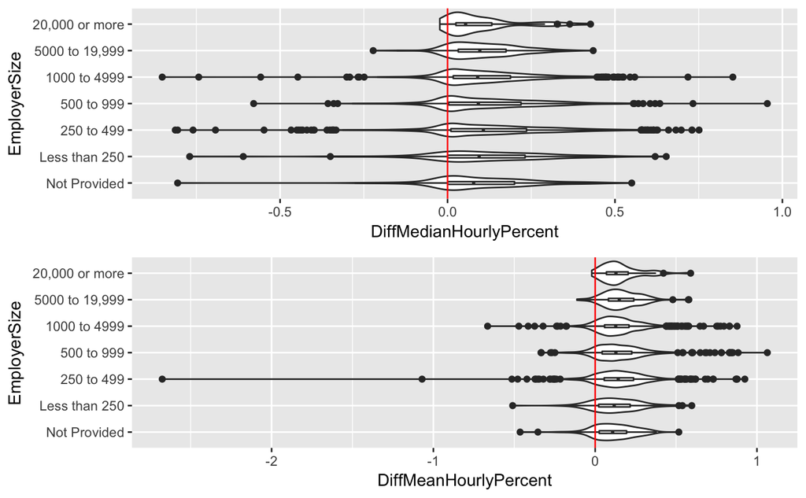

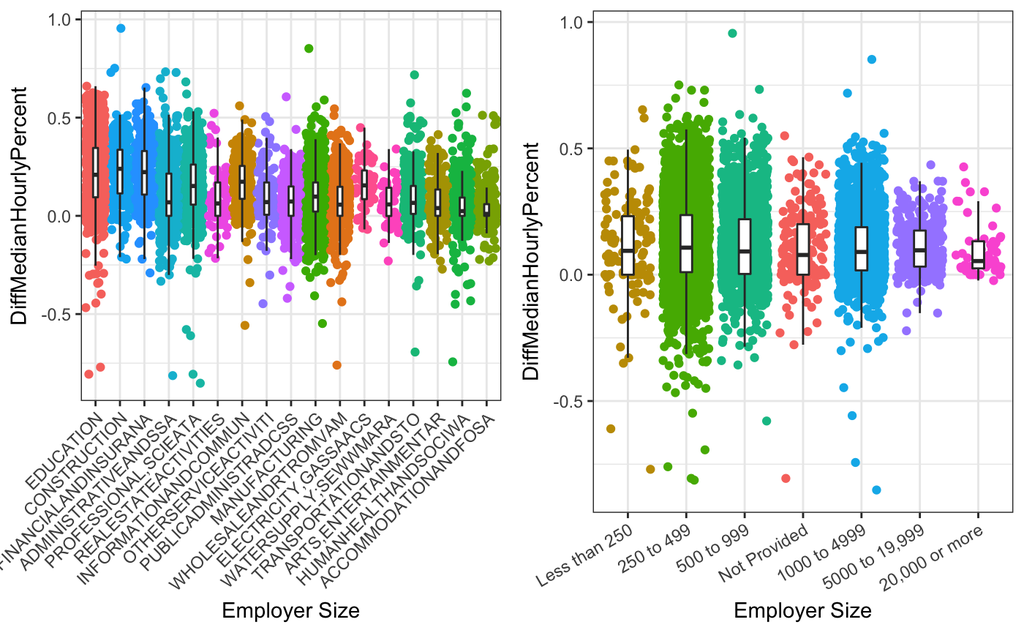

SIC division was identified as a more useful stratification variable. However, there was yet an obvious problem in that two of the divisions comprise just three companies each: activities of extraterritorial organisations and bodies, and activities of households as employers. We excluded these two divisions for the following reasons: 1. They comprise just 6 companies, making it difficult to sample in a representative way. 2. They contain less than 0.09% of population. 3. The divisions themselves have unique, specific characteristics. Therefore, it is not possible to combine them with other divisions in a meaningful way.

We then used a proportional-to-size (PPS) procedure to draw a stratified sample of (at most) 1000 companies. This technique ensures that the drawn sample well represents the population, given that the proportions of the divisions within the sample match those within the population. For example, the division $\textit{education}$ contains 986 companies, or 14.69% of the population. Within the PPS sample, education will comprise as close to this figure as possible. This method of sampling should ensure lower sampling errors, when comparing with an SRS. This is because a PPS stratified sample is expected to better represent the target population (in this case all UK companies with over 250 employees).

The PPS sample tells us that there is a 14.24% difference in the average wage - closer to the population value (14.4%) than the SRS (15.02%). The margin of error here is 0.74% (standard error = 0.0037645), which gives a sense of how far our predictions of the wage difference differ from the population values. This is calculated by 1.96*(s.e.), where 1.96 is the 95% z-value used to construct confidence intervals. The margin of error is, as expected, slightly lower than that of the SRS (0.8%). The design effect of 0.8771 means a sample of only 877 would be required to achieve the same precision as our earlier SRS. These figures indicate that we can more efficiently (design effect) and accurately (margin of error) make inferences on the population with this sampling design.

However, it is still possible to optimise the sample, via the choice of stratum sample size. This can be done by using a Neyman Allocation. This method allocates an optimal size for each stratum via the formula $\frac{(N_h * V_h)} {\Sigma (N_h * V_h)}$, where $N_h$ and $V_h$ are the stratum sizes and variances respectively. In this way, it is possible to oversample from certain strata - namely those with higher variances - in order to achieve a smaller standard error. According to this sampling design, the gender pay gap stands at 14.05%. While this underestimates the pay gap slightly more than the PPS sample, the standard error of 0.0037412 is marginally smaller in comparison. This means we now have a smaller, better design effect of 0.8685. Consequently, we consider this design more efficient than the PPS, requiring fewer companies to achieve the same precision. We therefore conclude that, when seeking to maximise precision within a sample of 1000 companies, stratifying based on SIC division and using Neyman’s optimal allocation is better than taking an SRS or a PPS stratified sample. Other sampling designs are beyond the scope of this report.

```r
# proportional-to-size stratified sample for 'division'
sample_stratum <- stratify(gpg_core, "division", n=1000, seed=400)

# Surveydesign for stratified sample
stratdesign_prop <- svydesign(ids=sample_stratum$uuid,
                              fpc=~fpc,
                              strata = ~Stratum,
                              data = sample_stratum)

# Calculate the population value & design effect
svymean(~DiffMeanHourlyPercent, design=stratdesign_prop, deff=TRUE)

# Use neyman allocation to stratify optimally
sample_optim <- stratify(gpg_core,
                         "division",
                         n=1000,
                         seed=400,
                         optim=TRUE,
                         optimVar = "DiffMeanHourlyPercent")

length(which(sample_optim$Stratum == 1))

# Surveydesign for stratified sample
sample_optim$Prob <- 1 / sample_optim$Prob
stratdesign_optim <- svydesign(ids=sample_optim$uuid,
                         fpc=~fpc,
                         strata = ~Stratum,
                         #weights = ~Prob,
                         data = sample_optim)


comparedesign <- data.frame(
  "Mean wage gap estimate" = c(as.numeric(svymean(~DiffMeanHourlyPercent, swordesign)),
                               as.numeric(svymean(~DiffMeanHourlyPercent, design=stratdesign_prop, deff=TRUE)),
                               as.numeric(svymean(~DiffMeanHourlyPercent, design=stratdesign_optim, deff=TRUE))),
  "SE" = c(as.numeric(SE(svymean(~DiffMeanHourlyPercent, swordesign))),
                       as.numeric(SE(svymean(~DiffMeanHourlyPercent, design=stratdesign_prop, deff=TRUE))),
                       as.numeric(SE(svymean(~DiffMeanHourlyPercent, design=stratdesign_optim, deff=TRUE)))),
  "Margin of error" = c(as.numeric(SE(svymean(~DiffMeanHourlyPercent, swordesign)))*1.96,
                       as.numeric(SE(svymean(~DiffMeanHourlyPercent, design=stratdesign_prop, deff=TRUE)))*1.96,
                       as.numeric(SE(svymean(~DiffMeanHourlyPercent, design=stratdesign_optim, deff=TRUE)))*1.96)
  #"Design Effect" = c(1, )
)
row.names(comparedesign) <- c("SRS", "PPS", "Optimised")
knitr::kable(comparedesign)
```

[output not shown]